# lab4_ZimengDing

```r
ccyes <- c(75, 62)
ccno <- c(25, 38)
state <- c('New Jersey', 'Kentucky')
contable <- rbind(ccyes, ccno)
colnames(contable) <- state
contable
```

```
##       New Jersey Kentucky
## ccyes         75       62
## ccno          25       38
```

```r
chisq.test(contable)
```

```
##
##  Pearson's Chi-squared test with Yates' continuity correction
##
## data:  contable
## X-squared = 3.3368, df = 1, p-value = 0.06775
```

## Exercise 1

# 1

Write out the null and alternate hypothesis for the chi-square test you just ran. Please interpret the result. Can you reject the null hypothesis at alpha = 0.05? What about at alpha = 0.10?

H0:The distribution of climate change beliefs is not different between New Jersey and Kentucky students?

Ha:The distribution of climate change beliefs is different between New Jersey and Kentucky students.

If alpha = 0.05, I can not reject the null hypothesis. If alpha = 0.1, I can reject the null hypothesis.

# 2

Now run the same analyses as above, but pick two different states. Use the same link I used [http://climatecommunication.yale.edu/visualizations-data/ycom-us-2016/?est=happening&type=value&geo=state] to get information on the % of people who believe global warming is happening in each state in the US. Hint - look at the numbers for Kentucky and New Jersey. How did I use these to parameterize my ccyes and ccno values above? Please do the same thing, but pick two different states.

```r
ccyes <- c(68, 67)
ccno <- c(12, 14)
state <- c('Michigan', 'Iowa')
contable <- rbind(ccyes, ccno)
colnames(contable) <- state
contable
```

```
##       Michigan Iowa
## ccyes       68   67
## ccno        12   14
```

```r
chisq.test(contable)
```

```
##
##  Pearson's Chi-squared test with Yates' continuity correction
##
## data:  contable
## X-squared = 0.032252, df = 1, p-value = 0.8575
```

```r
head(OrchardSprays)
```

```
##   decrease rowpos colpos treatment
## 1       57      1      1         D
## 2       95      2      1         E
## 3        8      3      1         B
## 4       69      4      1         H
## 5       92      5      1         G
## 6       90      6      1         F
```

```r
?OrchardSprays
```

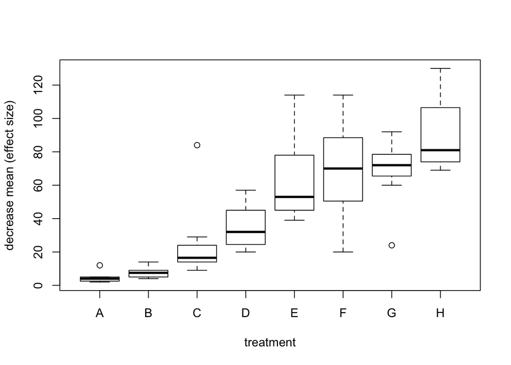

```r
boxplot(decrease ~ treatment, data = OrchardSprays, xlab = "treatment", ylab = "decrease mean (effect size)")
```

```r
spray.aov <- aov(decrease ~ treatment, data = OrchardSprays)
summary(spray.aov)
```

```
##             Df Sum Sq Mean Sq F value  Pr(>F)
## treatment    7  56160    8023   19.06 9.5e-13 ***
## Residuals   56  23570     421
## ---
## Signif. codes:  0 '***' 0.001 '**' 0.01 '*' 0.05 '.' 0.1 ' ' 1
```

```r
TukeyHSD(spray.aov)
```

```
##   Tukey multiple comparisons of means
##     95% family-wise confidence level
##
## Fit: aov(formula = decrease ~ treatment, data = OrchardSprays)
##
## $treatment
##       diff        lwr       upr     p adj
## B-A  3.000 -29.294313  35.29431 0.9999898
## C-A 20.625 -11.669313  52.91931 0.4842087
## D-A 30.375  -1.919313  62.66931 0.0795377
## E-A 58.500  26.205687  90.79431 0.0000123
## F-A 64.375  32.080687  96.66931 0.0000015
## G-A 63.875  31.580687  96.16931 0.0000018
## H-A 85.625  53.330687 117.91931 0.0000000
## C-B 17.625 -14.669313  49.91931 0.6756283
## D-B 27.375  -4.919313  59.66931 0.1540608
## E-B 55.500  23.205687  87.79431 0.0000357
## F-B 61.375  29.080687  93.66931 0.0000044
## G-B 60.875  28.580687  93.16931 0.0000052
## H-B 82.625  50.330687 114.91931 0.0000000
## D-C  9.750 -22.544313  42.04431 0.9793381
## E-C 37.875   5.580687  70.16931 0.0111133
## F-C 43.750  11.455687  76.04431 0.0018729
## G-C 43.250  10.955687  75.54431 0.0021935
## H-C 65.000  32.705687  97.29431 0.0000012
## E-D 28.125  -4.169313  60.41931 0.1316222
## F-D 34.000   1.705687  66.29431 0.0323055
## G-D 33.500   1.205687  65.79431 0.0368008
## H-D 55.250  22.955687  87.54431 0.0000390
## F-E  5.875 -26.419313  38.16931 0.9990714
## G-E  5.375 -26.919313  37.66931 0.9994801
## H-E 27.125  -5.169313  59.41931 0.1621616
## G-F -0.500 -32.794313  31.79431 1.0000000
## H-F 21.250 -11.044313  53.54431 0.4453236
## H-G 21.750 -10.544313  54.04431 0.4150331
```

## Exercise 2

# 1

Which treatments are significantly different from one another according to the results of the TukeyHSD (at the 0.05 level)?

# 2

Why do we use the Tukey’s HSD test instead of just running multiple t-tests that compare each pair of treatments in your sample?

Because running multiple t-tests wil result in increasing the error.

```r
head(CO2)
```

```
##   Plant   Type  Treatment conc uptake
## 1   Qn1 Quebec nonchilled   95   16.0
## 2   Qn1 Quebec nonchilled  175   30.4
## 3   Qn1 Quebec nonchilled  250   34.8
## 4   Qn1 Quebec nonchilled  350   37.2
## 5   Qn1 Quebec nonchilled  500   35.3
## 6   Qn1 Quebec nonchilled  675   39.2
```

```r
?CO2
```

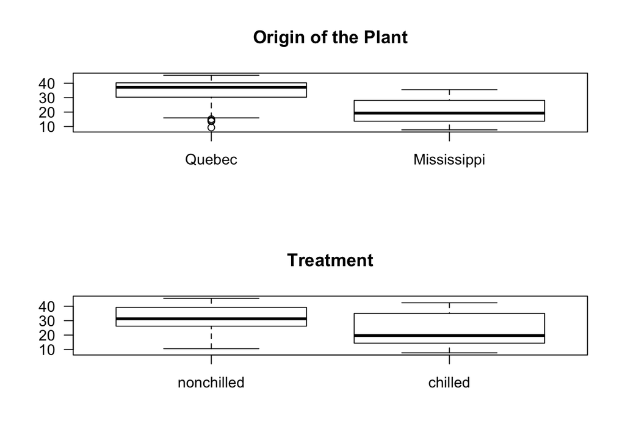

```r
par(mfrow = c(2, 1))
boxplot(uptake ~ Type,data = CO2, las = 1, main = 'Origin of the Plant')
boxplot(uptake ~ Treatment, data = CO2, las = 1, main = 'Treatment')
```

## Exercise 3

```r
CO2.aov <- aov(uptake~Treatment + Type, data = CO2)
summary(CO2.aov)
```

```
##             Df Sum Sq Mean Sq F value   Pr(>F)
## Treatment    1    988     988   14.95 0.000222 ***
## Type         1   3366    3366   50.92 3.68e-10 ***
## Residuals   81   5353      66
## ---
## Signif. codes:  0 '***' 0.001 '**' 0.01 '*' 0.05 '.' 0.1 ' ' 1
```

# 1

Please interpret the results of your two-way ANOVA. Which factors have a significant effect on CO2 uptake?

Both p-values of treatment and type are below 0.05. So treatment and type both have a significant effect on CO2 uptake.

## Exercise 4

```r
library(fivethirtyeight)
```

```r
head(bechdel)
```

```
##   year      imdb            title            test clean_test binary
## 1 2013 tt1711425        21 & Over          notalk     notalk   FAIL
## 2 2012 tt1343727         Dredd 3D     ok-disagree         ok   PASS
## 3 2013 tt2024544 12 Years a Slave notalk-disagree     notalk   FAIL
## 4 2013 tt1272878           2 Guns          notalk     notalk   FAIL
## 5 2013 tt0453562               42             men        men   FAIL
## 6 2013 tt1335975         47 Ronin             men        men   FAIL
##      budget domgross  intgross     code budget_2013 domgross_2013
## 1  13000000 25682380  42195766 2013FAIL    13000000      25682380
## 2  45000000 13414714  40868994 2012PASS    45658735      13611086
## 3  20000000 53107035 158607035 2013FAIL    20000000      53107035
## 4  61000000 75612460 132493015 2013FAIL    61000000      75612460
## 5  40000000 95020213  95020213 2013FAIL    40000000      95020213
## 6 225000000 38362475 145803842 2013FAIL   225000000      38362475
##   intgross_2013 period_code decade_code
## 1      42195766           1           1
## 2      41467257           1           1
## 3     158607035           1           1
## 4     132493015           1           1
## 5      95020213           1           1
## 6     145803842           1           1
```

# 1

Use an ANOVA to see if 2013 dollars (domgross_2013) differ based on whether a movie passed the Bechdel test or not (binary). Please write out the null and alternate hypothesis. Can you reject the null hypothesis at alpha = 0.05 based on the p value of your ANOVA? Please explain your results in non-technical terms.

```r
bechdel.aov <- aov(domgross_2013~binary, data =bechdel )
summary(bechdel.aov)
```

```
##               Df    Sum Sq   Mean Sq F value  Pr(>F)
## binary         1 3.487e+17 3.487e+17   22.24 2.6e-06 ***
## Residuals   1774 2.782e+19 1.568e+16
## ---
## Signif. codes:  0 '***' 0.001 '**' 0.01 '*' 0.05 '.' 0.1 ' ' 1
## 18 observations deleted due to missingness
```

```r
TukeyHSD(bechdel.aov)
```

```
##   Tukey multiple comparisons of means
##     95% family-wise confidence level
##
## Fit: aov(formula = domgross_2013 ~ binary, data = bechdel)
##
## $binary
##                diff       lwr       upr   p adj
## PASS-FAIL -28182452 -39903549 -16461356 2.6e-06
```

H0:2013 dollars do not differ based on whether a movie passed the Bechdel test or not. Ha:2013 dollars differ based on whether a movie passed the Bechdel test or not.

p value < 0.05 So the null hypothesis can be rejected. 2013 dollars differ based on whether a movie passed the Bechdel test or not.

# 2

Now run an ANOVA to see if 2013 dollars (domgross_2013) differ based on whether a movie passed the Bechdel test or not (binary) and the decade in which the movie was made (decade_code). Hint - Right now the decade_code variable is an integer and therefore not a categorical variable. To turn it into a categorical variable, please use ‘as.factor(decade_code)’ in your ANOVA function.

```r
bechdel2.aov <- aov(domgross_2013~binary +as.factor(decade_code) , data =bechdel)
summary(bechdel2.aov)
```

```
##                          Df    Sum Sq   Mean Sq F value   Pr(>F)
## binary                    1 8.681e+16 8.681e+16   8.995 0.002749 **
## as.factor(decade_code)    2 1.673e+17 8.363e+16   8.665 0.000181 ***
## Residuals              1596 1.540e+19 9.651e+15
## ---
## Signif. codes:  0 '***' 0.001 '**' 0.01 '*' 0.05 '.' 0.1 ' ' 1
## 194 observations deleted due to missingness
```

Both two p-values are below 0.05. 2013 dollars differ based on whether a movie passed the Bechdel test or not and the decade in which the movie was made.

# 3

BONUS/EXTRA CREDIT - worth 0.5% of total class grade Pick another dataset from within the fivethirtyeight package and run either a one way or two way ANOVA. Please write out the null and alternate hypothesis and state whether you can reject the null hypothesis based on your p value. Remember, in order for a dataset to work for this question, your indepdent variable has to be categorical (and have 2 or more categories) and your dependent variable has to be continuous. You can ask Harrison/Tori/Michael/Meha for help selecting an appropriate dataset, but please do not ask other students.

```r
head(candy_rankings)
```

```
##   competitorname chocolate fruity caramel peanutyalmondy nougat
## 1      100 Grand      TRUE  FALSE    TRUE          FALSE  FALSE
## 2   3 Musketeers      TRUE  FALSE   FALSE          FALSE   TRUE
## 3       One dime     FALSE  FALSE   FALSE          FALSE  FALSE
## 4    One quarter     FALSE  FALSE   FALSE          FALSE  FALSE
## 5      Air Heads     FALSE   TRUE   FALSE          FALSE  FALSE
## 6     Almond Joy      TRUE  FALSE   FALSE           TRUE  FALSE
##   crispedricewafer  hard   bar pluribus sugarpercent pricepercent
## 1             TRUE FALSE  TRUE    FALSE        0.732        0.860
## 2            FALSE FALSE  TRUE    FALSE        0.604        0.511
## 3            FALSE FALSE FALSE    FALSE        0.011        0.116
## 4            FALSE FALSE FALSE    FALSE        0.011        0.511
## 5            FALSE FALSE FALSE    FALSE        0.906        0.511
## 6            FALSE FALSE  TRUE    FALSE        0.465        0.767
##   winpercent
## 1   66.97173
## 2   67.60294
## 3   32.26109
## 4   46.11650
## 5   52.34146
## 6   50.34755
```

```r
candy.aov <- aov(winpercent~chocolate, data =candy_rankings)
summary(candy.aov)
```

```
##             Df Sum Sq Mean Sq F value   Pr(>F)
## chocolate    1   7369    7369   56.53 5.86e-11 ***
## Residuals   83  10818     130
## ---
## Signif. codes:  0 '***' 0.001 '**' 0.01 '*' 0.05 '.' 0.1 ' ' 1
```

“The Ultimate Halloween Candy Power Ranking”"

H0: Whether it contains chocolate does not have a significant effect on the overall win percentage of candy.

Ha: Whether it contains chocolate has a significant effect on the overall win percentage of candy.

chocolate: p-value < 0.05

Null hypothesis can be rejected. So Whether it contains chocolate has a significant effect on the overall win percentage of candy.